# T.S HW2

# 2.5 Daily Log Return of GBPTWD

## Time Plot

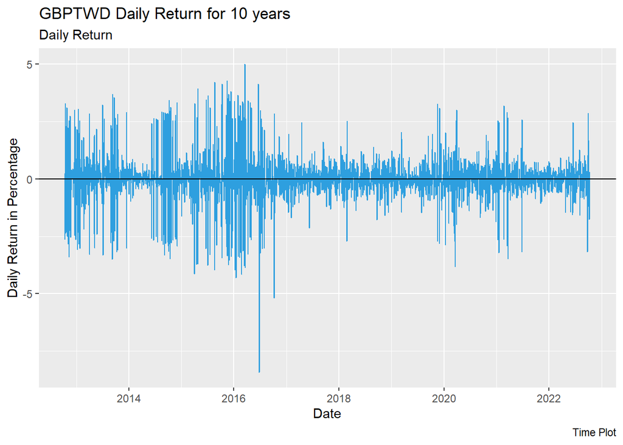

## ACF、PAC & Ljung Box Test

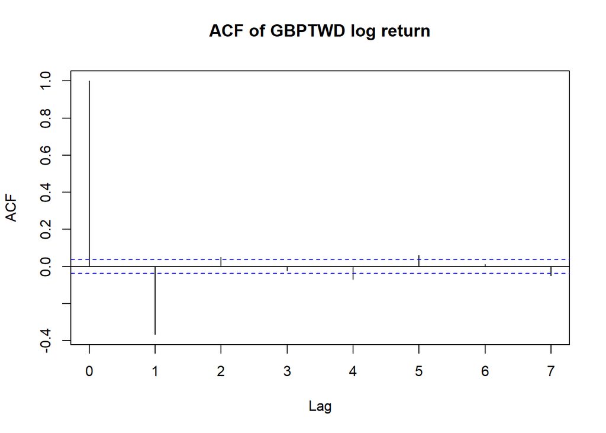

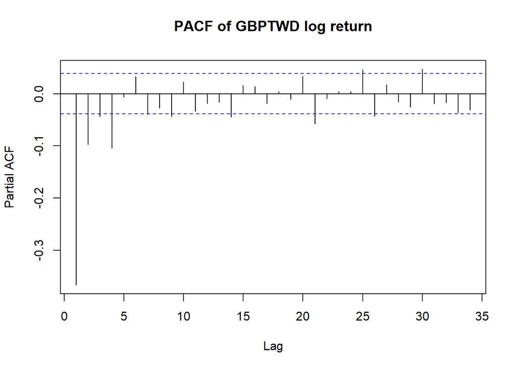

```
##
##  Box-Ljung test
##
## data:  data
## X-squared = 396.32, df = 10, p-value < 2.2e-16
```

# 2.6 Daily Log Return of USDGBP

## Time Plot

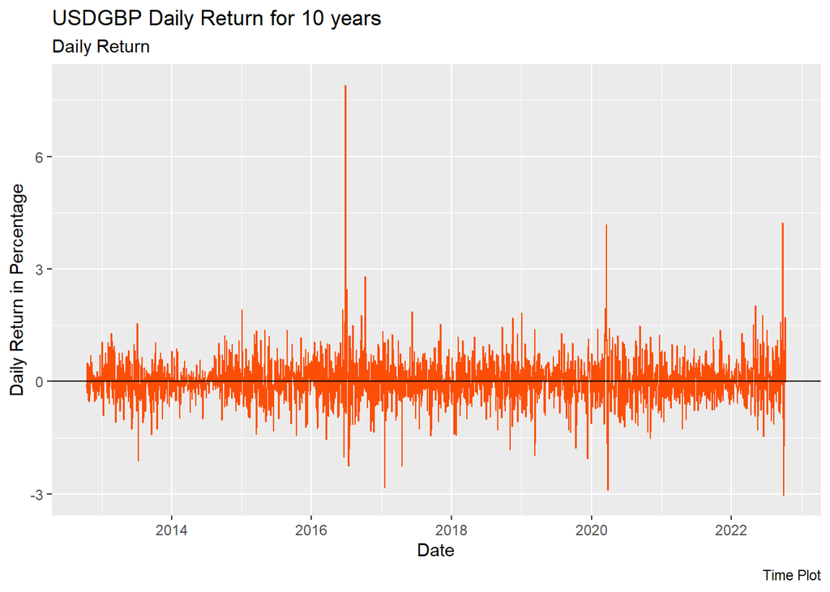

從上圖可以看到除了2016年10月英鎊美元貨幣對閃崩、2020年初、2022年尾有短暫的震盪，英鎊美元貨幣對的日報酬的波動度皆平穩大約在-2~2之間，其對數日報酬的變化也與日報酬的變化相仿。

## ACF、PAC & Ljung Box Test

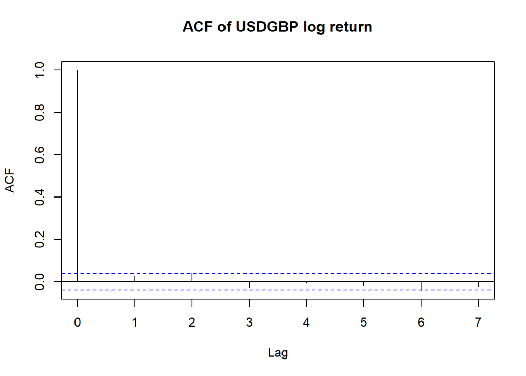

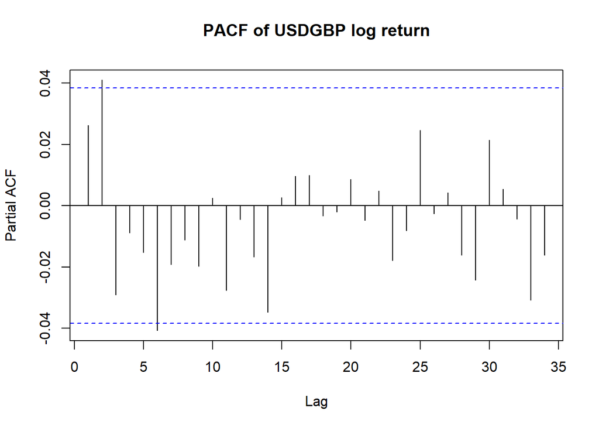

```
##
##  Box-Ljung test
##
## data:  data
## X-squared = 16.547, df = 10, p-value = 0.08502
```

從上圖美金英鎊貨幣對的日報酬的ACF中沒有看到指數遞減的現象，pacf圖中的lag也多為不顯著 ，由此判斷資料並不存在自我相關性，此外，Ljung Box test其p-value=0.08502 > 0.05，意味著資料之間不存在序列相關性，故美金英鎊貨幣對不會做後續AR的建模。

# Conclusion of Simple Return and Log Return for three stock index and it’s currency pair.

比較三種指數的Time plot可以看到倫敦100(FTSE)與美國標普500(SP500)的趨勢較為相仿，雖然兩者在ACF皆看不出自我相關性，但若更進一步做Ljung Box test皆為顯數，存在序列相關，故我們仍會以檢定結果作為依據建立AR model。 大盤指數的acf圖多為cutoff，pacf顯著的lag錯落於前幾根，而貨幣對的acf圖多為只有lag1顯著，pacf前幾個lag顯著。 其中台指與美元英鎊貨幣對不論是ACF或Ljung Box Test的結果皆不顯著，故我們後續不會做TWII的AR Model.

# 3 AR Model and Model Diagnostic

## 3.1 SP500

### Simple Return

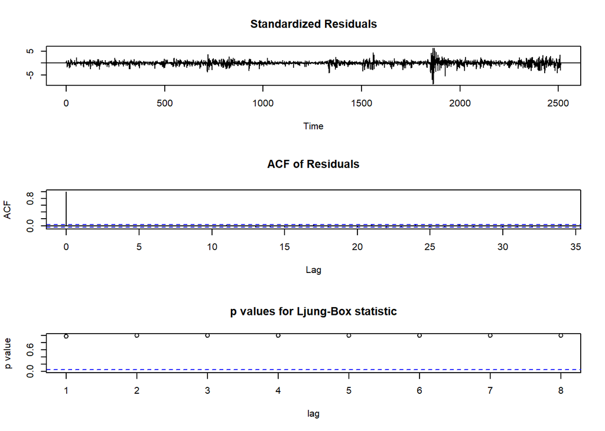

```
## $AIC
##          0          1          2          3          4          5          6
## 172.744853 121.323457 111.389641 113.297331 101.271697 102.032315  80.183238
##          7          8          9         10         11         12
##  40.538826  21.033488   1.954600   0.000000   1.360316   3.272164
##
## $mle.order
## [1] 10
##
## $m1
##
## Call:
## ar(x = data, method = "mle")
##
## Coefficients:
##       1        2        3        4        5        6        7        8
## -0.0948   0.0453   0.0131  -0.0727   0.0071  -0.0772   0.1122  -0.0803
##       9       10
##  0.0867  -0.0400
##
## Order selected 10  sigma^2 estimated as  1.105
##
## $m2
##
## Call:
## arima(x = data, order = c(m1$order, 0, 0))
##
## Coefficients:
##           ar1     ar2     ar3      ar4     ar5      ar6     ar7      ar8
##       -0.0947  0.0452  0.0132  -0.0727  0.0072  -0.0772  0.1121  -0.0802
## s.e.   0.0199  0.0199  0.0199   0.0198  0.0198   0.0198  0.0199   0.0200
##          ar9     ar10  intercept
##       0.0879  -0.0399     0.0427
## s.e.  0.0201   0.0201     0.0191
##
## sigma^2 estimated as 1.105:  log likelihood = -3693.1,  aic = 7410.2
##
## $`Residual Box Test`
##
##  Box-Ljung test
```

[output cut: 9 more lines]

```
## $sigma2
## [1] 1.051269
##
## $roots
##  [1]  0.9662984+0.9923273i -1.0324614+0.4422296i -1.0324614-0.4422296i
##  [4]  0.9662984-0.9923273i  0.1171164+1.4496132i -0.6115561+1.1474228i
##  [7] -0.6115561-1.1474228i  1.6617824-0.3672652i  1.6617824+0.3672652i
## [10]  0.1171164-1.4496132i
##
## $modulus
##  [1] 1.385080 1.123185 1.123185 1.385080 1.454337 1.300223 1.300223 1.701883
##  [9] 1.701883 1.454337
##
## $`business cycle`
## [1] 7.866896
```

由於SP500日報酬的ACF沒有指數遞減的現象，也無法從圖中判斷AR模型的order p，故我們用AIC來選擇order p，並根據其選出的order p建立AR模型，再做後續的殘差檢定。 從上面AIC、mle.order、m1的結果可以看到，若用AIC挑選模型，當p=10的時候AIC最小，故SP500日報酬以AR(10)建模。 從m2的結果可以看到，其coefficient在lag3、lag5與lag10的時候並不顯著，其餘皆為顯著的。

殘差的部分不論從ACF來看或是做Ljung Box Test結果皆不顯著，表示殘差已無自相關，已符合模型對white noise的假設，完成AR(10)的建模。

### Log Return

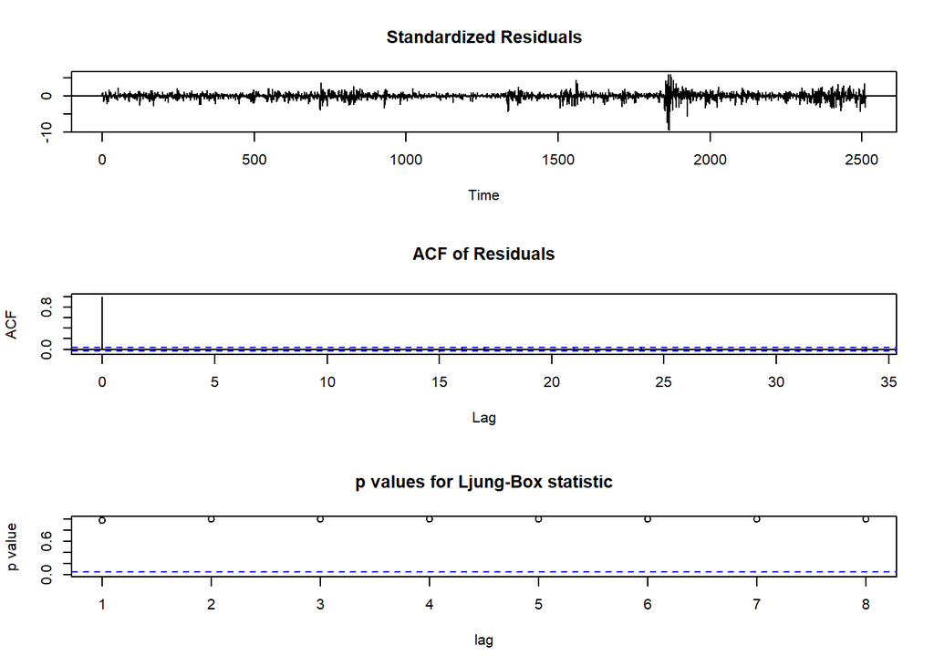

```
## $AIC
##          0          1          2          3          4          5          6
## 169.719764 119.840657 107.828274 109.499904  99.171336  99.369625  79.350345
##          7          8          9         10         11         12
##  40.077602  20.484775   1.686557   0.000000   1.256584   3.007871
##
## $mle.order
## [1] 10
##
## $m1
##
## Call:
## ar(x = data, method = "mle")
##
## Coefficients:
##       1        2        3        4        5        6        7        8
## -0.0923   0.0522   0.0185  -0.0677   0.0118  -0.0736   0.1114  -0.0805
##       9       10
##  0.0871  -0.0386
##
## Order selected 10  sigma^2 estimated as  1.115
##
## $m2
##
## Call:
## arima(x = data, order = c(m1$order, 0, 0))
##
## Coefficients:
##           ar1     ar2     ar3      ar4     ar5      ar6     ar7      ar8
##       -0.0922  0.0522  0.0185  -0.0677  0.0118  -0.0736  0.1114  -0.0805
## s.e.   0.0199  0.0199  0.0199   0.0198  0.0198   0.0199  0.0199   0.0200
##          ar9     ar10  intercept
##       0.0875  -0.0385     0.0367
## s.e.  0.0201   0.0201     0.0197
##
## sigma^2 estimated as 1.115:  log likelihood = -3704.79,  aic = 7433.57
##
## $`Residual Box Test`
##
##  Box-Ljung test
```

[output cut: 9 more lines]

```
## $sigma2
## [1] 1.056169
##
## $roots
##  [1]  0.9743934+0.9986023i -1.0333612+0.4425230i -1.0333612-0.4425230i
##  [4]  0.9743934-0.9986023i  0.1265715+1.4542759i -0.6108969+1.1477703i
##  [7] -0.6108969-1.1477703i  1.6795048-0.3318180i  1.6795048+0.3318180i
## [10]  0.1265715-1.4542759i
##
## $modulus
##  [1] 1.395224 1.124127 1.124127 1.395224 1.459773 1.300220 1.300220 1.711970
##  [9] 1.711970 1.459773
##
## $`business cycle`
## [1] 7.876947
```

與SP500日報酬的作法相仿，由於SP500對數日報酬的ACF沒有指數遞減的現象，也無法從圖中判斷AR模型的order p，故我們用AIC來選擇order p，並根據其選出的order p建立AR模型，再做後續的殘差檢定 。 從上面結果可以看到AIC、mle.order、m1的結果與SP500日報酬的結果相仿，故我們仍以AR(10)對SP500的對數日報酬建模。

從m2的結果可以看到，其coefficient在lag3、lag5與lag10的時候並不顯著，其餘皆為顯著的。

殘差的部分不論從ACF來看或是做Ljung Box Test結果皆不顯著，表示殘差已無自相關，已符合模型對white noise的假設，完成AR(10)的建模。

## 3.2 FTSE

### Simple Return

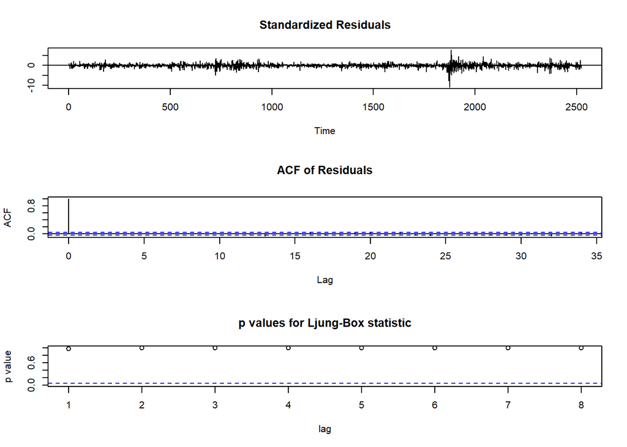

```
## $AIC
##         0         1         2         3         4         5         6         7
## 15.106452 16.218607 17.672296 19.543639 19.465742 20.482294 16.091422  5.359415
##         8         9        10        11        12
##  0.000000  1.584864  3.176309  5.175684  6.905701
##
## $mle.order
## [1] 8
##
## $m1
##
## Call:
## ar(x = data, method = "mle")
##
## Coefficients:
##       1        2        3        4        5        6        7        8
## -0.0097  -0.0206   0.0104  -0.0311   0.0204  -0.0500   0.0702  -0.0541
##
## Order selected 8  sigma^2 estimated as  0.9881
##
## $m2
##
## Call:
## arima(x = data, order = c(m1$order, 0, 0))
##
## Coefficients:
##           ar1      ar2     ar3      ar4     ar5      ar6     ar7      ar8
##       -0.0097  -0.0206  0.0104  -0.0311  0.0204  -0.0500  0.0702  -0.0541
## s.e.   0.0199   0.0198  0.0198   0.0198  0.0198   0.0198  0.0198   0.0199
##       intercept
##          0.0118
## s.e.     0.0186
##
## sigma^2 estimated as 0.9881:  log likelihood = -3566.3,  aic = 7152.6
##
## $`Residual Box Test`
##
##  Box-Ljung test
##
## data:  m2$residuals
## X-squared = 0.48487, df = 10, p-value = 1
##
##
## $phi0_hat
##  intercept
## 0.01257534
##
## $sigma2
## [1] 0.9940199
##
## $roots
## [1]  0.718007+1.335969i -1.147206+0.573529i -1.147206-0.573529i
## [4]  1.473599-0.590149i -0.395961+1.334266i -0.395961-1.334266i
## [7]  0.718007-1.335969i  1.473599+0.590149i
##
## $modulus
## [1] 1.516690 1.282583 1.282583 1.587379 1.391780 1.391780 1.516690 1.587379
##
## $`business cycle`
## [1] 5.830477
```

與SP500的狀況雷同，有鑑於FTSE日報酬的ACF沒有指數遞減的現象，也無法從圖中判斷AR模型的order p，故我們用AIC來選擇order p，並根據其選出的order p建立AR模型，再做後續的殘差檢定。

從上面AIC、mle.order、m1的結果可以看到，若用AIC挑選模型，當p=8的時候AIC最小，故FTSE日報酬以AR(8)建模。

從m2的結果可以看到，其coefficient在lag1~lag5皆不顯著，直到lag6以後才較為顯著。

殘差的部分不論從ACF來看或是做Ljung Box Test結果皆不顯著，表示殘差已無自相關，已符合模型對white noise的假設，完成AR(8)的建模。

另外，在弱平穩的的AR模型中，$E(r_t)=0\quad iff \quad \phi_0=0$，從上述結果可以看到$\hat{\phi_0}=0.01257534$與m2中intercept $E(r_t)=0.0118$的值相近。

### Log Return

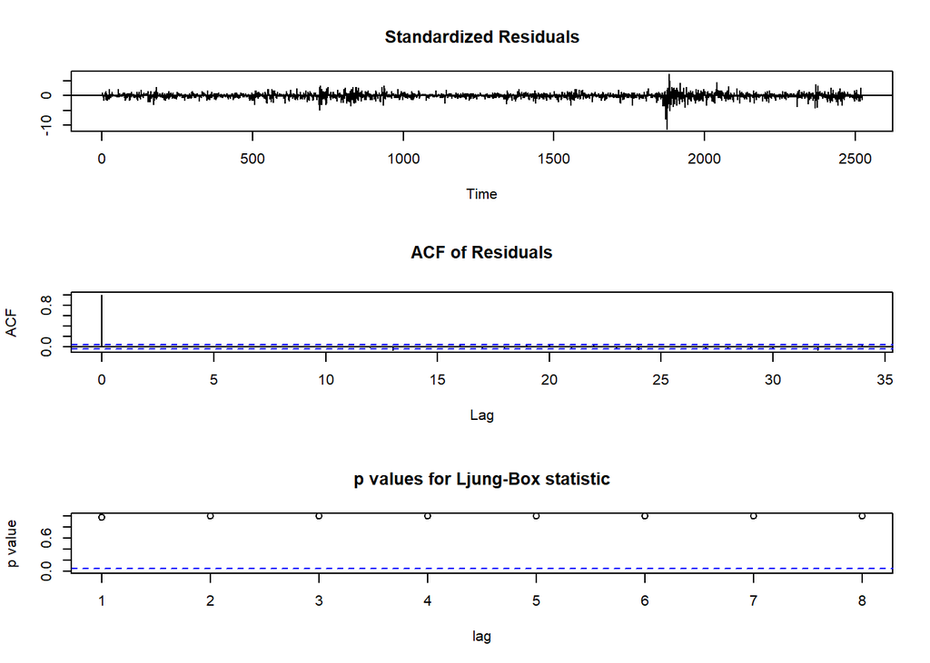

```
## $AIC
##         0         1         2         3         4         5         6         7
## 15.388981 16.514575 18.038913 19.754360 20.100349 21.093286 16.793665  5.435268
##         8         9        10        11        12
##  0.000000  1.525200  3.204368  5.180622  6.949497
##
## $mle.order
## [1] 8
##
## $m1
##
## Call:
## ar(x = data, method = "mle")
##
## Coefficients:
##       1        2        3        4        5        6        7        8
## -0.0093  -0.0194   0.0139  -0.0281   0.0208  -0.0496   0.0719  -0.0544
##
## Order selected 8  sigma^2 estimated as  0.9953
##
## $m2
##
## Call:
## arima(x = data, order = c(m1$order, 0, 0))
##
## Coefficients:
##           ar1      ar2     ar3      ar4     ar5      ar6     ar7      ar8
##       -0.0093  -0.0195  0.0139  -0.0281  0.0208  -0.0496  0.0719  -0.0544
## s.e.   0.0199   0.0198  0.0198   0.0198  0.0198   0.0198  0.0198   0.0199
##       intercept
##          0.0068
## s.e.     0.0188
##
## sigma^2 estimated as 0.9953:  log likelihood = -3575.54,  aic = 7171.08
##
## $`Residual Box Test`
##
##  Box-Ljung test
##
## data:  m2$residuals
## X-squared = 0.46416, df = 10, p-value = 1
##
##
## $phi0_hat
##   intercept
## 0.007184453
##
## $sigma2
## [1] 0.9976649
##
## $roots
## [1]  0.719502+1.334831i -1.146121+0.572436i -1.146121-0.572436i
## [4]  1.480916-0.580873i -0.393388+1.330116i -0.393388-1.330116i
## [7]  0.719502-1.334831i  1.480916+0.580873i
##
## $modulus
## [1] 1.516396 1.281123 1.281123 1.590762 1.387070 1.387070 1.516396 1.590762
##
## $`business cycle`
## [1] 5.837107
```

與FTSE日報酬的作法相仿，FTSE的對數日報酬我們仍用AIC來選擇order p，並根據其選出的order p建立AR模型，再做後續的殘差檢定。

從上面AIC、mle.order、m1的結果可以看到，若用AIC挑選模型，當p=8的時候AIC最小，故FTSE對數日報酬以AR(8)建模。

從m2的結果可以看到，其coefficient在lag1~lag5皆不顯著，直到lag6以後才較為顯著。

殘差的部分不論從ACF來看或是做Ljung Box Test結果皆不顯著，表示殘差已無自相關，已符合模型對white noise的假設，完成AR(8)的建模。

另外，在弱平穩的的AR模型中，$E(r_t)=0\quad iff \quad \phi_0=0$，從上述結果可以看到$\hat{\phi_0}=0.007184453$與m2中intercept $E(r_t)=0.0068$的值相近。

## 3.3 USD/TWD

### Simple Return

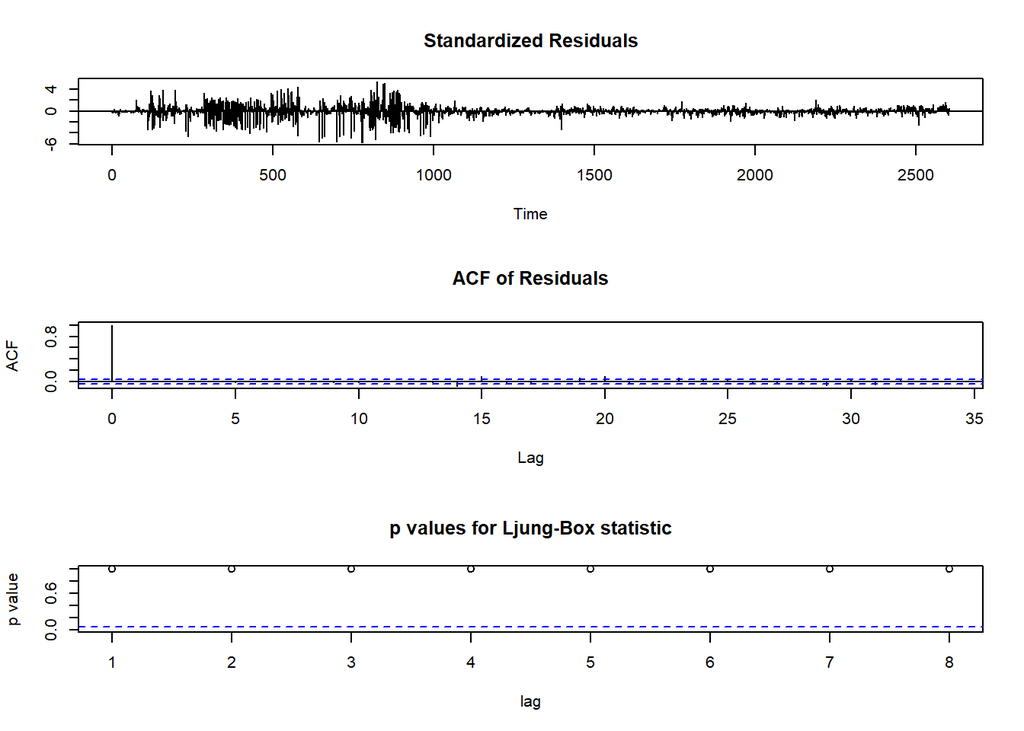

```
## $AIC
##          0          1          2          3          4          5          6
## 877.259625 357.823987 203.971277 155.612012  55.082300  30.528438  23.309876
##          7          8          9         10         11         12
##  25.136376  22.699744   6.362258   1.912217   0.000000   1.986987
##
## $mle.order
## [1] 11
##
## $m1
##
## Call:
## ar(x = data, method = "mle")
##
## Coefficients:
##       1        2        3        4        5        6        7        8
## -0.6044  -0.3774  -0.2610  -0.2451  -0.0892   0.0415  -0.0259  -0.0623
##       9       10       11
## -0.0386   0.0732   0.0388
##
## Order selected 11  sigma^2 estimated as  0.5453
##
## $m2
##
## Call:
## arima(x = data, order = c(m1$order, 0, 0))
##
## Coefficients:
##           ar1      ar2     ar3      ar4      ar5     ar6      ar7      ar8
##       -0.6044  -0.3774  -0.261  -0.2451  -0.0892  0.0414  -0.0259  -0.0623
## s.e.   0.0196   0.0228   0.024   0.0245   0.0250  0.0250   0.0250   0.0245
##           ar9    ar10    ar11  intercept
##       -0.0386  0.0731  0.0387     0.0070
## s.e.   0.0240  0.0228  0.0195     0.0057
##
## sigma^2 estimated as 0.5453:  log likelihood = -2905.74,  aic = 5837.48
##
## $`Residual Box Test`
##
##  Box-Ljung test
```

[output cut: 9 more lines]

```
## $sigma2
## [1] 0.7384496
##
## $roots
##  [1]  0.3988587+1.0961915i -0.9737946+0.8150561i -0.9737946-0.8150561i
##  [4]  1.0360345-0.8303684i  1.0360345+0.8303684i -1.3189198+0.0000000i
##  [7] -0.4512979-1.1617371i  1.5345379+0.0000000i -0.4512979+1.1617371i
## [10] -2.1244296-0.0000000i  0.3988587-1.0961915i
##
## $modulus
##  [1] 1.166501 1.269879 1.269879 1.327735 1.327735 1.318920 1.246316 1.534538
##  [9] 1.246316 2.124430 1.166501
##
## $`business cycle`
## [1] 5.142442
```

```
## [1] 11
```

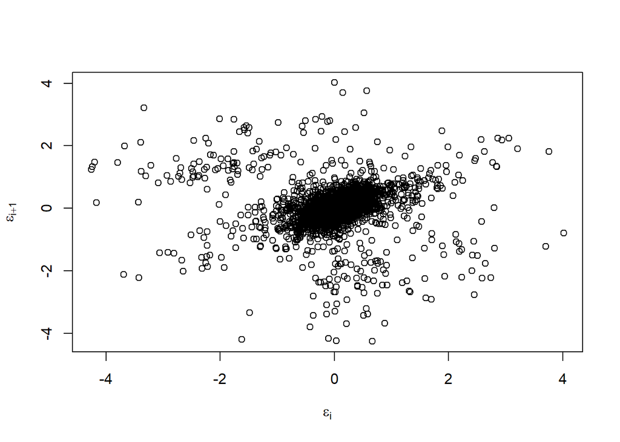

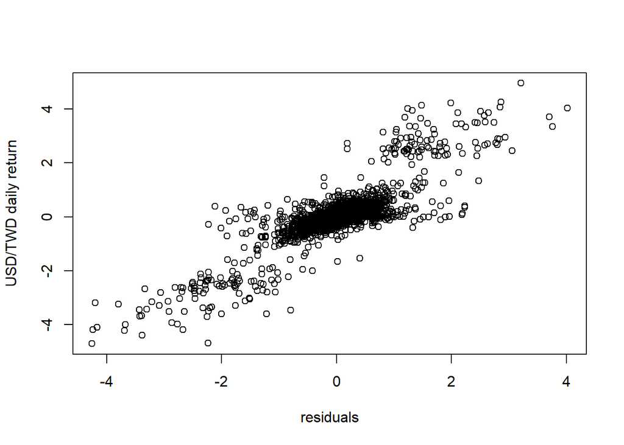

從上面AIC、mle.order、m1的結果可以看到，若用AIC挑選模型，當p=11的時候AIC最小，故USD/TWD日報酬以AR(11)建模。

從m2的結果可以看到，其coefficient在lag6、lag7、lag9、lag11時皆不顯著，其餘皆為顯著的。

殘差的部分不論從ACF來看或是做Ljung Box Test結果皆不顯著，表示殘差已無自相關，但觀察 $\epsilon_{i+1}$ - $\epsilon_{i}$ plot 跟資料點與殘差圖可以發現，不僅殘差間有明顯疏密程度差異，殘差與資料間也有正相關的趨勢。

另外，在弱平穩的的AR模型中，$E(r_t)=0\quad iff \quad \phi_0=0$，從上述結果可以看到$=0.0179 $與m2中intercept $E(r_t)=0.0070$的值相近。

### Log Return

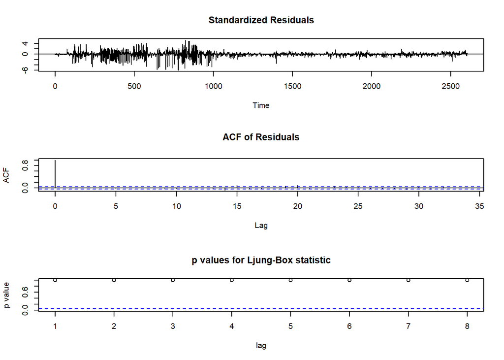

```
## $AIC
##          0          1          2          3          4          5          6
## 878.002886 358.999297 205.821177 157.340903  55.312053  29.983526  23.149056
##          7          8          9         10         11         12
##  24.972704  22.725235   6.532126   1.938666   0.000000   1.979226
##
## $mle.order
## [1] 11
##
## $m1
##
## Call:
## ar(x = data, method = "mle")
##
## Coefficients:
##       1        2        3        4        5        6        7        8
## -0.6046  -0.3780  -0.2628  -0.2479  -0.0911   0.0409  -0.0249  -0.0609
##       9       10       11
## -0.0379   0.0738   0.0389
##
## Order selected 11  sigma^2 estimated as  0.5456
##
## $m2
##
## Call:
## arima(x = data, order = c(m1$order, 0, 0))
##
## Coefficients:
##           ar1      ar2      ar3      ar4      ar5     ar6      ar7      ar8
##       -0.6046  -0.3780  -0.2629  -0.2479  -0.0911  0.0409  -0.0249  -0.0609
## s.e.   0.0196   0.0228   0.0240   0.0245   0.0250  0.0250   0.0250   0.0245
##           ar9    ar10    ar11  intercept
##       -0.0379  0.0738  0.0388     0.0032
## s.e.   0.0240  0.0228  0.0195     0.0057
##
## sigma^2 estimated as 0.5456:  log likelihood = -2906.4,  aic = 5838.81
##
## $`Residual Box Test`
##
##  Box-Ljung test
```

[output cut: 9 more lines]

```
## $sigma2
## [1] 0.7386375
##
## $roots
##  [1]  0.3997221+1.0964854i -0.9734298+0.8139848i -0.9734298-0.8139848i
##  [4]  1.0330390-0.8323399i  1.0330390+0.8323399i -1.3179008-0.0000000i
##  [7] -0.4509002-1.1614484i  1.5313266-0.0000000i -0.4509002+1.1614484i
## [10] -2.1293139+0.0000000i  0.3997221-1.0964854i
##
## $modulus
##  [1] 1.167072 1.268912 1.268912 1.326635 1.326635 1.317901 1.245903 1.531327
##  [9] 1.245903 2.129314 1.167072
##
## $`business cycle`
## [1] 5.145007
```

```
## [1] 11
```

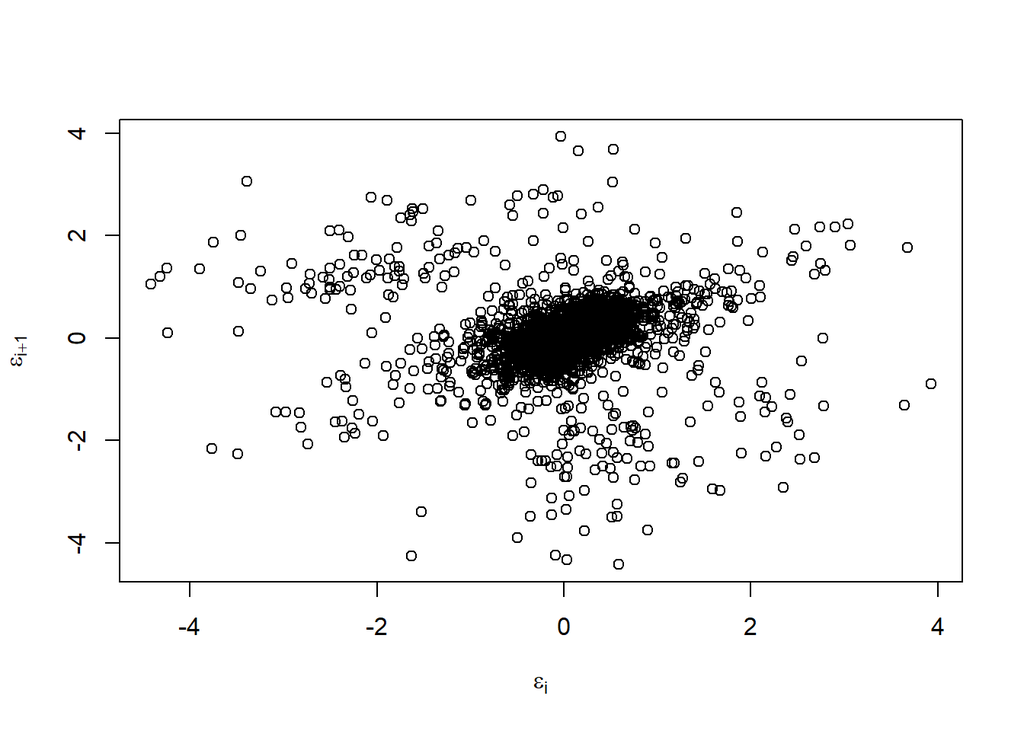

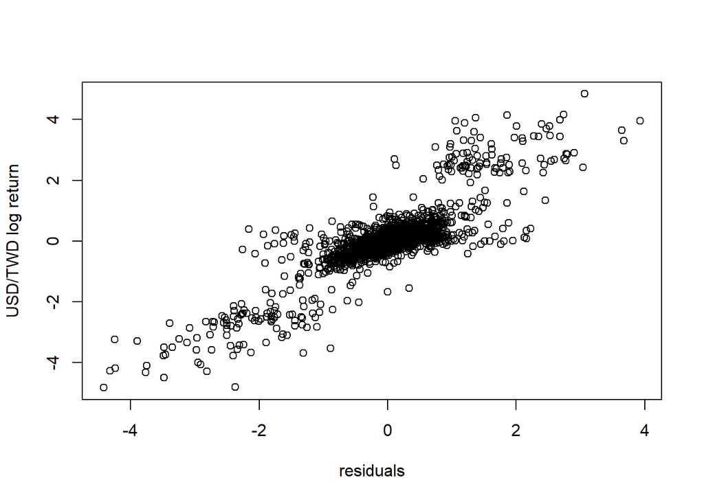

從上面AIC、mle.order、m1的結果可以看到，若用AIC挑選模型，當p=11的時候AIC最小，故USD/TWD日報酬以AR(11)建模。

從m2的結果可以看到，其coefficient在lag6、lag7、lag9、lag11時皆不顯著，其餘皆為顯著的。

殘差的部分不論從ACF來看或是做Ljung Box Test結果皆不顯著，表示殘差已無自相關，同樣的觀察 $\epsilon_{i+1}$ - $\epsilon_{i}$ plot 跟資料點與殘差圖可以發現，不僅殘差間有明顯疏密程度差異，殘差與資料間也有正相關的趨勢。

## 3.4 GBP/TWD

### Simple Return

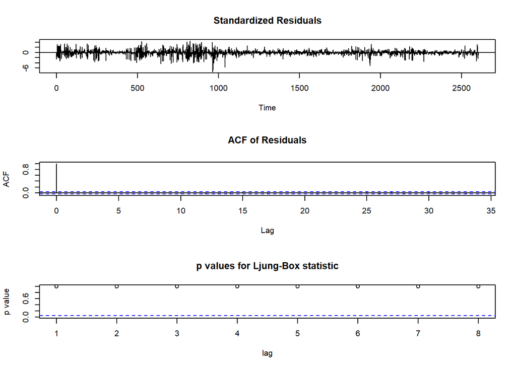

```
## $AIC
##           0           1           2           3           4           5
## 435.3078203  57.9393202  34.0831509  30.9010945   4.0714192   6.4018508
##           6           7           8           9          10          11
##   5.6933404   3.5913122   3.4390118   0.2252084   0.9772269   0.0000000
##          12
##   1.0026593
##
## $mle.order
## [1] 11
##
## $m1
##
## Call:
## ar(x = data, method = "mle")
##
## Coefficients:
##       1        2        3        4        5        6        7        8
## -0.4141  -0.1289  -0.0896  -0.1120  -0.0072   0.0107  -0.0593  -0.0476
##       9       10       11
## -0.0402   0.0078  -0.0341
##
## Order selected 11  sigma^2 estimated as  0.8797
##
## $m2
##
## Call:
## arima(x = data, order = c(m1$order, 0, 0))
##
## Coefficients:
##           ar1      ar2      ar3      ar4      ar5     ar6      ar7      ar8
##       -0.4142  -0.1288  -0.0897  -0.1119  -0.0081  0.0110  -0.0601  -0.0469
## s.e.   0.0196   0.0212   0.0213   0.0214   0.0215  0.0215   0.0216   0.0215
##           ar9    ar10     ar11  intercept
##       -0.0409  0.0088  -0.0351    -0.0055
## s.e.   0.0215  0.0214   0.0198     0.0096
##
## sigma^2 estimated as 0.8795:  log likelihood = -3530.57,  aic = 7087.13
##
## $`Residual Box Test`
```

[output cut: 11 more lines]

```
## $sigma2
## [1] 0.9378095
##
## $roots
##  [1]  0.815619+1.275557i -1.035876+0.716072i -1.035876-0.716072i
##  [4]  1.250694-0.528506i  0.317992+1.363932i -1.235264-0.000000i
##  [7] -0.606107-1.177811i  1.250694+0.528506i -0.606107+1.177811i
## [10]  0.317992-1.363932i  0.815619-1.275557i
##
## $modulus
##  [1] 1.514028 1.259285 1.259285 1.357776 1.400510 1.235264 1.324615 1.357776
##  [9] 1.324615 1.400510 1.514028
##
## $`business cycle`
## [1] 6.271309
```

```
## [1] 11
```

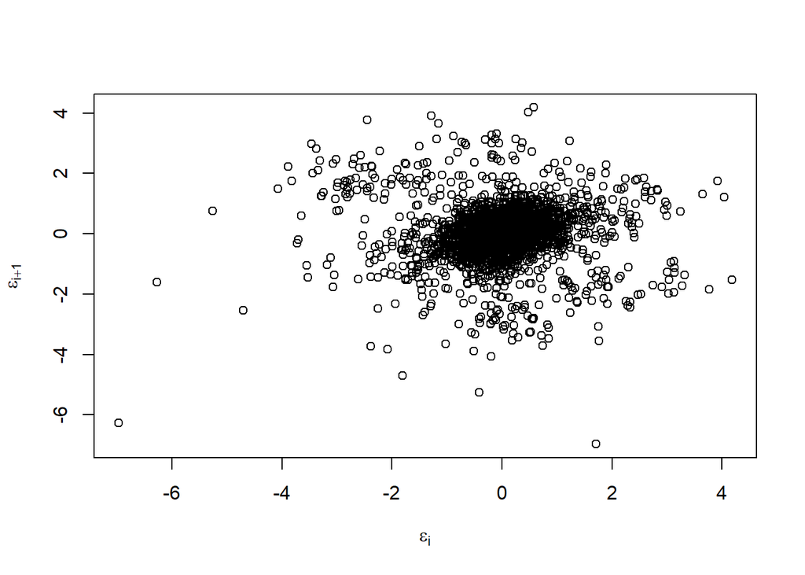

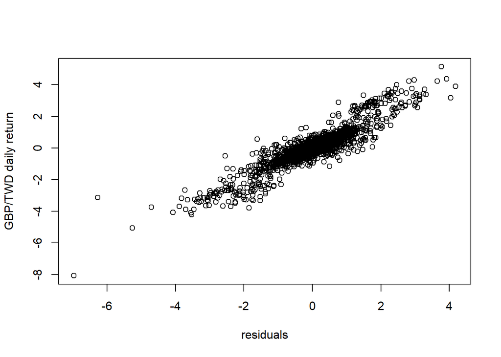

殘差的部分不論從ACF來看或是做Ljung Box Test結果皆不顯著，表示殘差已無自相關，同美金台幣貨幣對 $\epsilon_{i+1}$ - $\epsilon_{i}$ plot 跟資料點與殘差圖可以發現，不僅殘差間有明顯疏密程度差異，殘差與資料間也有正相關的趨勢。

另外，在弱平穩的的AR模型中，$E(r_t)=0\quad iff \quad \phi_0=0$，從上述結果可以看到$=–0.01055 $與m2中intercept $E(r_t)=-0.0055$的值相近。

### Log Return

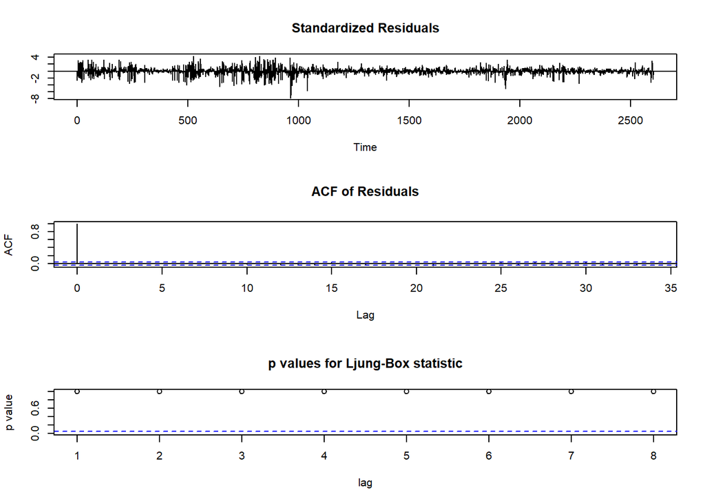

```
## $AIC
##           0           1           2           3           4           5
## 430.6491308  56.5555346  33.5405416  30.2809277   3.5897336   6.0375437
##           6           7           8           9          10          11
##   5.1571497   3.2729580   3.2630609   0.2997576   0.8794928   0.0000000
##          12
##   1.0599686
##
## $mle.order
## [1] 11
##
## $m1
##
## Call:
## ar(x = data, method = "mle")
##
## Coefficients:
##       1        2        3        4        5        6        7        8
## -0.4114  -0.1265  -0.0881  -0.1102  -0.0039   0.0128  -0.0573  -0.0459
##       9       10       11
## -0.0384   0.0096  -0.0335
##
## Order selected 11  sigma^2 estimated as  0.8837
##
## $m2
##
## Call:
## arima(x = data, order = c(m1$order, 0, 0))
##
## Coefficients:
##           ar1      ar2      ar3      ar4      ar5     ar6      ar7      ar8
##       -0.4115  -0.1264  -0.0882  -0.1101  -0.0047  0.0131  -0.0581  -0.0452
## s.e.   0.0196   0.0212   0.0213   0.0214   0.0215  0.0215   0.0215   0.0215
##           ar9    ar10     ar11  intercept
##       -0.0391  0.0105  -0.0346    -0.0108
## s.e.   0.0215  0.0214   0.0198     0.0097
##
## sigma^2 estimated as 0.8836:  log likelihood = -3536.57,  aic = 7099.14
##
## $`Residual Box Test`
```

[output cut: 11 more lines]

```
## $sigma2
## [1] 0.9399741
##
## $roots
##  [1]  0.828106+1.278994i -1.034786+0.715540i -1.034786-0.715540i
##  [4]  1.259318-0.528503i  0.321788+1.357521i -1.235662-0.000000i
##  [7] -0.604593-1.178679i  1.259318+0.528503i -0.604593+1.178679i
## [10]  0.321788-1.357521i  0.828106-1.278994i
##
## $modulus
##  [1] 1.523675 1.258085 1.258085 1.365722 1.395138 1.235662 1.324695 1.365722
##  [9] 1.324695 1.395138 1.523675
##
## $`business cycle`
## [1] 6.307128
```

```
## [1] 11
```

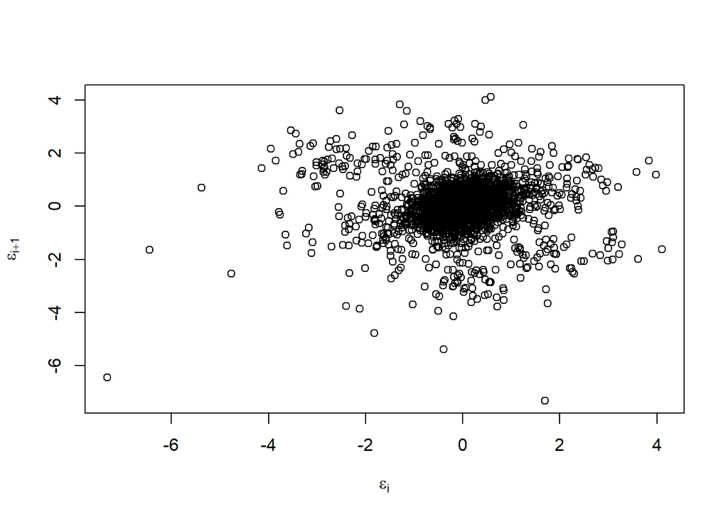

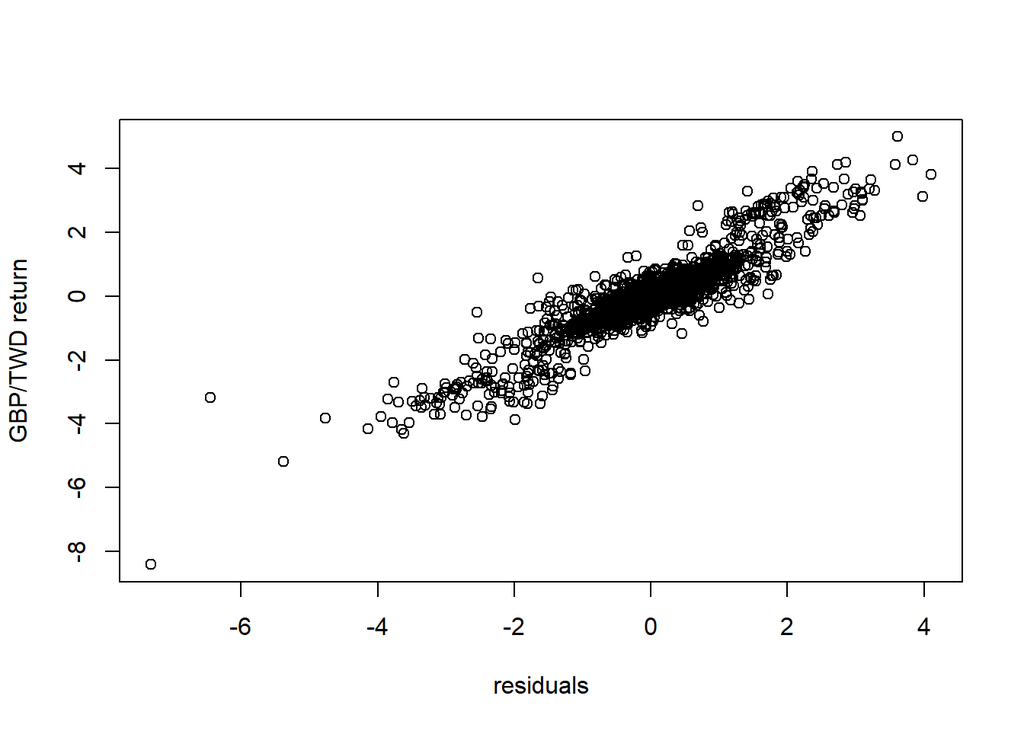

殘差的部分不論從ACF來看或是做Ljung Box Test結果皆不顯著，表示殘差已無自相關，透過$\epsilon_{i+1}$ - $\epsilon_{i}$ plot 跟資料點與殘差圖可以發現，不僅殘差間有明顯疏密程度差異，殘差與資料間也有正相關的趨勢。。

另外，在弱平穩的的AR模型中，$E(r_t)=0\quad iff \quad \phi_0=0$，從上述結果可以看到$=–0.0204 $與m2中intercept $E(r_t)=-0.0108$的值相近。

整體來說FTSE fit AR model後的coefficient大多不顯著，並沒有SP500的好，且從一開始SP500與FTSE的ACF便沒有指數遞減的現象，而所選的貨幣對其殘差皆有所規則含有未能解釋的資訊，或許這四比資料並不適用AR模型，故未來或許需考量用其他模型fit這兩筆資料。